# Advanced Analytical Approach in Glioma Grading Using Clinical and Genetic Data

Aymen Maqsood

03/12/2023

### Summary

In this project, I aim to develop a model for accurately grading gliomas using clinical and genetic data. Using R libraries, I’ve worked on data preparation, including cleaning and feature engineering. The project progresses with splitting the data into training and testing sets. I’ve focused on building KNN and Naive Bayes, along with logistic regression and SVM. These models are used to grade gliomas using clinical and genetic data

## Importing required Libraries

```r
# install.packages("tidyverse")
# install.packages("klaR")
# install.packages("rpart")
# install.packages("randomForest")
# install.packages("caret")
# install.packages("e1071")
# install.packages("DataExplorer")
# install.packages("gridExtra")
# install.packages("psych")
# install.packages("class")
# install.packages("Metrics")
# install.packages("kernlab")

library(tidyverse)
library(klaR)
library(rpart)
library(dplyr)
library(randomForest)
library(caret)
library(e1071)
library(MASS)
library(DataExplorer)
library(ggplot2)
library(gridExtra)
library(psych)
library(class)
library(caret)
library(Metrics)
library(pROC)
library(kernlab)
library(randomForest)
```

1. Data Acquisition

## loading DATA

- For Importing data, I have used read.csv function.
- Using head function, I observed first few rows of the data
- Since almost all the features are categorical, I have kept stringsAsFactors = True

```r
# https://docs.google.com/spreadsheets/d/1onsNlZd5VjhOALMmkIHuveSAlQKnVsp2d4Z4fzYcyws/export?format=csv
#TCGA_infoWithGrade.csv

##############################
###      DATA LOADING      ###
##############################

#Importing Dataset
df <- read.csv("https://docs.google.com/spreadsheets/d/1onsNlZd5VjhOALMmkIHuveSAlQKnVsp2d4Z4fzYcyws/export?format=csv" ,
               stringsAsFactors = TRUE )

#Exploring Dataset
head(df)
```

|  | Grade | Gender | Age_at_diagnosis | Race | IDH1 | TP53 | ATRX | PTEN | EGFR | CIC | MUC16 | PIK3CA | NF1 | PIK3R1 | FUBP1 | RB1 | NOTCH1 | BCOR | CSMD3 | SMARCA4 | GRIN2A | IDH2 | FAT4 | PDGFRA |
| --- | --- | --- | --- | --- | --- | --- | --- | --- | --- | --- | --- | --- | --- | --- | --- | --- | --- | --- | --- | --- | --- | --- | --- | --- |
| 1 | 0 | 0 | 51.30 | 0 | 1 | 0 | 0 | 0 | 0 | 0 | 0 | 1 | 0 | 0 | 1 | 0 | 0 | 0 | 0 | 0 | 0 | 0 | 0 | 0 |
| 2 | 0 | 0 | 38.72 | 0 | 1 | 0 | 0 | 0 | 0 | 1 | 0 | 0 | 0 | 0 | 0 | 0 | 0 | 0 | 0 | 0 | 0 | 0 | 0 | 0 |
| 3 | 0 | 0 | 35.17 | 0 | 1 | 1 | 1 | 0 | 0 | 0 | 0 | 0 | 0 | 0 | 0 | 0 | 0 | 0 | 0 | 0 | 0 | 0 | 0 | 0 |
| 4 | 0 | 1 | 32.78 | 0 | 1 | 1 | 1 | 0 | 0 | 0 | 1 | 0 | 0 | 1 | 0 | 0 | 0 | 0 | 0 | 0 | 0 | 0 | 1 | 0 |
| 5 | 0 | 0 | 31.51 | 0 | 1 | 1 | 1 | 0 | 0 | 0 | 0 | 0 | 0 | 0 | 0 | 0 | 0 | 0 | 0 | 0 | 0 | 0 | 0 | 0 |
| 6 | 0 | 1 | 33.21 | 0 | 1 | 0 | 1 | 0 | 0 | 0 | 0 | 0 | 0 | 0 | 0 | 0 | 0 | 0 | 0 | 0 | 0 | 0 | 0 | 0 |

```r
str(df)
```

```
## 'data.frame':    839 obs. of  24 variables:
##  $ Grade           : int  0 0 0 0 0 0 0 0 0 0 ...
##  $ Gender          : int  0 0 0 1 0 1 1 1 1 0 ...
##  $ Age_at_diagnosis: num  51.3 38.7 35.2 32.8 31.5 ...
##  $ Race            : int  0 0 0 0 0 0 0 0 0 0 ...
##  $ IDH1            : int  1 1 1 1 1 1 1 1 1 0 ...
##  $ TP53            : int  0 0 1 1 1 0 1 1 1 0 ...
##  $ ATRX            : int  0 0 1 1 1 1 0 1 1 0 ...
##  $ PTEN            : int  0 0 0 0 0 0 0 0 0 0 ...
##  $ EGFR            : int  0 0 0 0 0 0 0 0 0 0 ...
##  $ CIC             : int  0 1 0 0 0 0 0 0 0 0 ...
##  $ MUC16           : int  0 0 0 1 0 0 0 0 0 0 ...
##  $ PIK3CA          : int  1 0 0 0 0 0 0 0 0 0 ...
##  $ NF1             : int  0 0 0 0 0 0 0 0 0 0 ...
##  $ PIK3R1          : int  0 0 0 1 0 0 0 0 0 0 ...
##  $ FUBP1           : int  1 0 0 0 0 0 0 0 0 0 ...
##  $ RB1             : int  0 0 0 0 0 0 0 0 0 0 ...
##  $ NOTCH1          : int  0 0 0 0 0 0 0 0 0 0 ...
##  $ BCOR            : int  0 0 0 0 0 0 0 0 0 0 ...
##  $ CSMD3           : int  0 0 0 0 0 0 0 0 0 0 ...
##  $ SMARCA4         : int  0 0 0 0 0 0 0 0 0 0 ...
##  $ GRIN2A          : int  0 0 0 0 0 0 0 0 0 0 ...
##  $ IDH2            : int  0 0 0 0 0 0 0 0 0 0 ...
##  $ FAT4            : int  0 0 0 1 0 0 0 0 0 0 ...
##  $ PDGFRA          : int  0 0 0 0 0 0 0 0 0 0 ...
```

```r
summary(df)
```

```
##      Grade            Gender       Age_at_diagnosis      Race
##  Min.   :0.0000   Min.   :0.0000   Min.   :14.42    Min.   :0.0000
##  1st Qu.:0.0000   1st Qu.:0.0000   1st Qu.:38.05    1st Qu.:0.0000
##  Median :0.0000   Median :0.0000   Median :51.55    Median :0.0000
##  Mean   :0.4195   Mean   :0.4184   Mean   :50.94    Mean   :0.1073
##  3rd Qu.:1.0000   3rd Qu.:1.0000   3rd Qu.:62.80    3rd Qu.:0.0000
##  Max.   :1.0000   Max.   :1.0000   Max.   :89.29    Max.   :3.0000
##       IDH1             TP53             ATRX             PTEN
##  Min.   :0.0000   Min.   :0.0000   Min.   :0.0000   Min.   :0.0000
##  1st Qu.:0.0000   1st Qu.:0.0000   1st Qu.:0.0000   1st Qu.:0.0000
##  Median :0.0000   Median :0.0000   Median :0.0000   Median :0.0000
##  Mean   :0.4815   Mean   :0.4148   Mean   :0.2586   Mean   :0.1681
##  3rd Qu.:1.0000   3rd Qu.:1.0000   3rd Qu.:1.0000   3rd Qu.:0.0000
##  Max.   :1.0000   Max.   :1.0000   Max.   :1.0000   Max.   :1.0000
##       EGFR             CIC             MUC16            PIK3CA
##  Min.   :0.0000   Min.   :0.0000   Min.   :0.0000   Min.   :0.00000
##  1st Qu.:0.0000   1st Qu.:0.0000   1st Qu.:0.0000   1st Qu.:0.00000
##  Median :0.0000   Median :0.0000   Median :0.0000   Median :0.00000
##  Mean   :0.1335   Mean   :0.1323   Mean   :0.1168   Mean   :0.08701
##  3rd Qu.:0.0000   3rd Qu.:0.0000   3rd Qu.:0.0000   3rd Qu.:0.00000
##  Max.   :1.0000   Max.   :1.0000   Max.   :1.0000   Max.   :1.00000
##       NF1              PIK3R1            FUBP1              RB1
##  Min.   :0.00000   Min.   :0.00000   Min.   :0.00000   Min.   :0.00000
##  1st Qu.:0.00000   1st Qu.:0.00000   1st Qu.:0.00000   1st Qu.:0.00000
##  Median :0.00000   Median :0.00000   Median :0.00000   Median :0.00000
##  Mean   :0.07986   Mean   :0.06436   Mean   :0.05364   Mean   :0.04768
##  3rd Qu.:0.00000   3rd Qu.:0.00000   3rd Qu.:0.00000   3rd Qu.:0.00000
##  Max.   :1.00000   Max.   :1.00000   Max.   :1.00000   Max.   :1.00000
##      NOTCH1             BCOR             CSMD3            SMARCA4
##  Min.   :0.00000   Min.   :0.00000   Min.   :0.00000   Min.   :0.00000
##  1st Qu.:0.00000   1st Qu.:0.00000   1st Qu.:0.00000   1st Qu.:0.00000
##  Median :0.00000   Median :0.00000   Median :0.00000   Median :0.00000
##  Mean   :0.04529   Mean   :0.03456   Mean   :0.03218   Mean   :0.03218
##  3rd Qu.:0.00000   3rd Qu.:0.00000   3rd Qu.:0.00000   3rd Qu.:0.00000
##  Max.   :1.00000   Max.   :1.00000   Max.   :1.00000   Max.   :1.00000
##      GRIN2A             IDH2              FAT4             PDGFRA
##  Min.   :0.00000   Min.   :0.00000   Min.   :0.00000   Min.   :0.00000
##  1st Qu.:0.00000   1st Qu.:0.00000   1st Qu.:0.00000   1st Qu.:0.00000
##  Median :0.00000   Median :0.00000   Median :0.00000   Median :0.00000
##  Mean   :0.03218   Mean   :0.02741   Mean   :0.02741   Mean   :0.02622
##  3rd Qu.:0.00000   3rd Qu.:0.00000   3rd Qu.:0.00000   3rd Qu.:0.00000
##  Max.   :1.00000   Max.   :1.00000   Max.   :1.00000   Max.   :1.00000
```

```r
## creating copy of data for further anlaysis
c_df <- df
```

2. Data Exploration

### plots

- The plot_intro function from the DataExplorer package serves as an initial examination tool, offering a glimpse into the nature of the data at hand and identifying any gaps where information may be lacking.
- I have also used str and summary to understand the structure of the data present
- To calculate the number of missing Values(NA) present in the data I have created a function inside sapply , it returns column name and NA present in it
- To understand the distribution of the data, I have plotted each column in barplot
- findings :
1. Grade and Gender are categorical, encoded as integers.
2. Age_at_diagnosis is a continuous variable, represented as a float. The remaining variables (Race, IDH1, TP53, ATRX, PTEN, EGFR, CIC, MUC16, PIK3CA,NF1, PIK3R1, FUBP1, RB1, NOTCH1, BCOR, CSMD3, SMARCA4, GRIN2A, IDH2, FAT4, PDGFRA) appear to be categorical, as they are encoded as integers, which could represent different categories or binary (0/1) indicators for gene mutations.
3. There are no missing values , hence i will randomly input some missing values in further analysis

### Chi-Square Test Results:

1. Variables like **Gender, PIK3CA, CSMD3, and FAT4** show p-values greater than 0.05, indicating no significant statistical association with the Grade variable.Based on this I think I will be Dropping the Gender column as it does not have any effect on the target variable.
2. On the other hand, variables such as **Race, IDH1, TP53, ATRX, PTEN, EGFR, CIC, MUC16, NF1, PIK3R1, FUBP1, RB1, NOTCH1, SMARCA4, GRIN2A, IDH2, and PDGFR**A have p-values less than 0.05, suggesting a potential statistically significant association with Grade.

### Target variable

in the dataset **Grade** is the target variable containing 2 factor levels . Glioma grade class information (0 = “LGG”; 1 = “GBM”)** ,

** LGG (Lower-Grade Glioma) or GBM (Glioblastoma Multiforme)

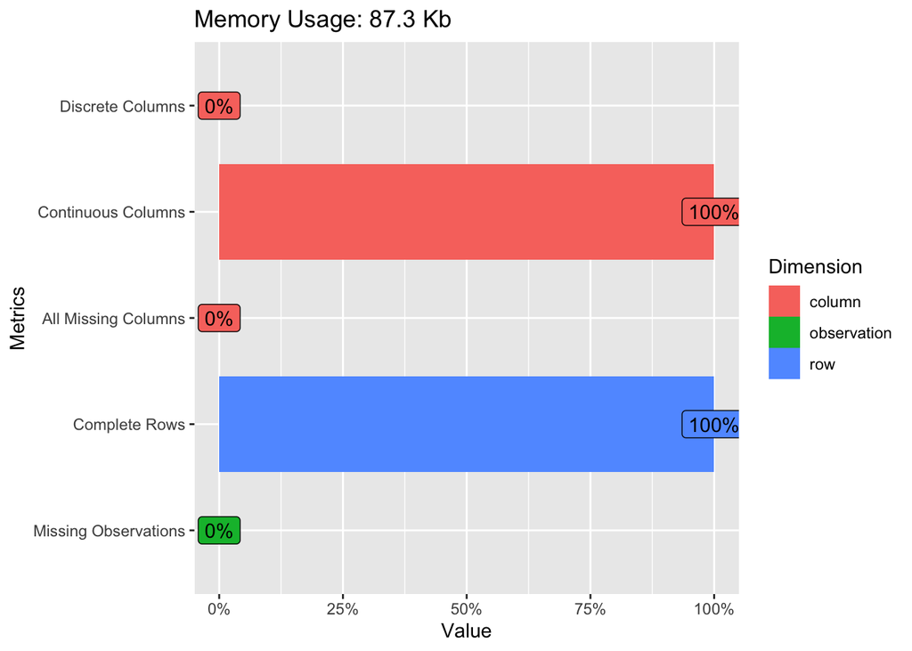

```r
##############################
###      DATA EXPLORATION  ###
##############################


#Visualizing structure of the dataset
plot_intro(df)
```

```r
# summary(df)

# checking for missign values
sapply(df, function(x) sum(is.na(x)))
```

```
##            Grade           Gender Age_at_diagnosis             Race
##                0                0                0                0
##             IDH1             TP53             ATRX             PTEN
##                0                0                0                0
##             EGFR              CIC            MUC16           PIK3CA
##                0                0                0                0
##              NF1           PIK3R1            FUBP1              RB1
##                0                0                0                0
##           NOTCH1             BCOR            CSMD3          SMARCA4
##                0                0                0                0
##           GRIN2A             IDH2             FAT4           PDGFRA
##                0                0                0                0
```

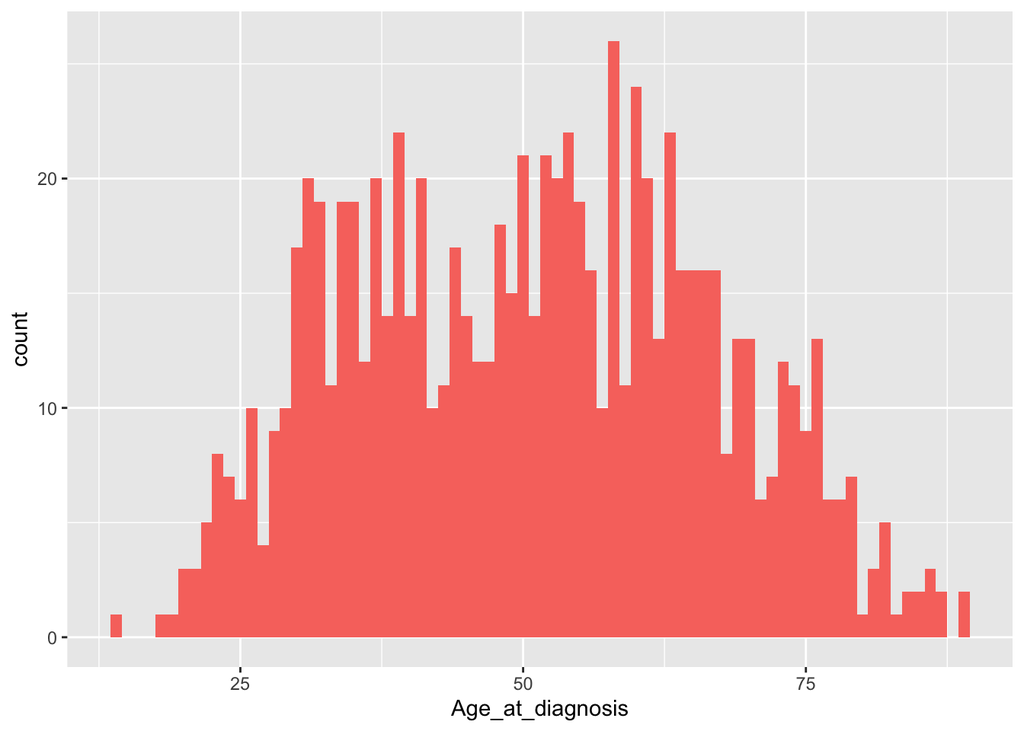

```r
# Plotting the distribution of the important features
# Continuous Variable
g1 <- ggplot(df, aes(x = Age_at_diagnosis, fill = "Steelblue")) + geom_histogram(binwidth = 1) + theme(legend.position = "none")

# Categorical Variables
g2 <- ggplot(df, aes(x = Grade, fill = factor(Grade))) + geom_bar() + theme(legend.position = "none")
g3 <- ggplot(df, aes(x = Gender, fill = factor(Gender))) + geom_bar() + theme(legend.position = "none")
g4 <- ggplot(df, aes(x = Race, fill = factor(Race))) + geom_bar() + theme(legend.position = "none")
g5 <- ggplot(df, aes(x = IDH1, fill = factor(IDH1))) + geom_bar() + theme(legend.position = "none")
g6 <- ggplot(df, aes(x = TP53, fill = factor(TP53))) + geom_bar() + theme(legend.position = "none")
g7 <- ggplot(df, aes(x = ATRX, fill = factor(ATRX))) + geom_bar() + theme(legend.position = "none")
g8 <- ggplot(df, aes(x = PTEN, fill = factor(PTEN))) + geom_bar() + theme(legend.position = "none")
g9 <- ggplot(df, aes(x = EGFR, fill = factor(EGFR))) + geom_bar() + theme(legend.position = "none")
g10 <- ggplot(df, aes(x = CIC, fill = factor(CIC))) + geom_bar() + theme(legend.position = "none")
g11 <- ggplot(df, aes(x = MUC16, fill = factor(MUC16))) + geom_bar() + theme(legend.position = "none")
g12 <- ggplot(df, aes(x = PIK3CA, fill = factor(PIK3CA))) + geom_bar() + theme(legend.position = "none")
g13 <- ggplot(df, aes(x = NF1, fill = factor(NF1))) + geom_bar() + theme(legend.position = "none")
g14 <- ggplot(df, aes(x = PIK3R1, fill = factor(PIK3R1))) + geom_bar() + theme(legend.position = "none")
g15 <- ggplot(df, aes(x = FUBP1, fill = factor(FUBP1))) + geom_bar() + theme(legend.position = "none")
g16 <- ggplot(df, aes(x = RB1, fill = factor(RB1))) + geom_bar() + theme(legend.position = "none")
g17 <- ggplot(df, aes(x = NOTCH1, fill = factor(NOTCH1))) + geom_bar() + theme(legend.position = "none")
g18 <- ggplot(df, aes(x = BCOR, fill = factor(BCOR))) + geom_bar() + theme(legend.position = "none")
g19 <- ggplot(df, aes(x = CSMD3, fill = factor(CSMD3))) + geom_bar() + theme(legend.position = "none")
g20 <- ggplot(df, aes(x = SMARCA4, fill = factor(SMARCA4))) + geom_bar() + theme(legend.position = "none")
g21 <- ggplot(df, aes(x = GRIN2A, fill = factor(GRIN2A))) + geom_bar() + theme(legend.position = "none")
g22 <- ggplot(df, aes(x = IDH2, fill = factor(IDH2))) + geom_bar() + theme(legend.position = "none")
g23 <- ggplot(df, aes(x = FAT4, fill = factor(FAT4))) + geom_bar() + theme(legend.position = "none")
g24 <- ggplot(df, aes(x = PDGFRA, fill = factor(PDGFRA))) + geom_bar() + theme(legend.position = "none")


# display the continous variable
g1
```

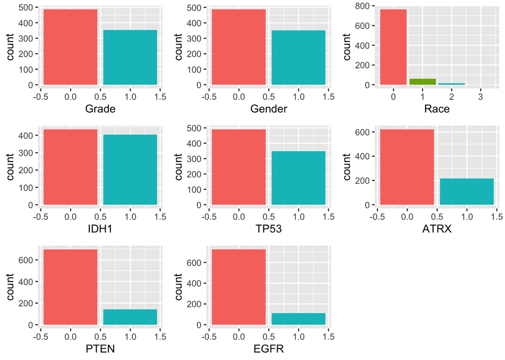

```r
#Arranging the plots using grid.arrange function
grid.arrange(g2,g3,g4,g5,g6,g7,g8,g9,nrow=3)
```

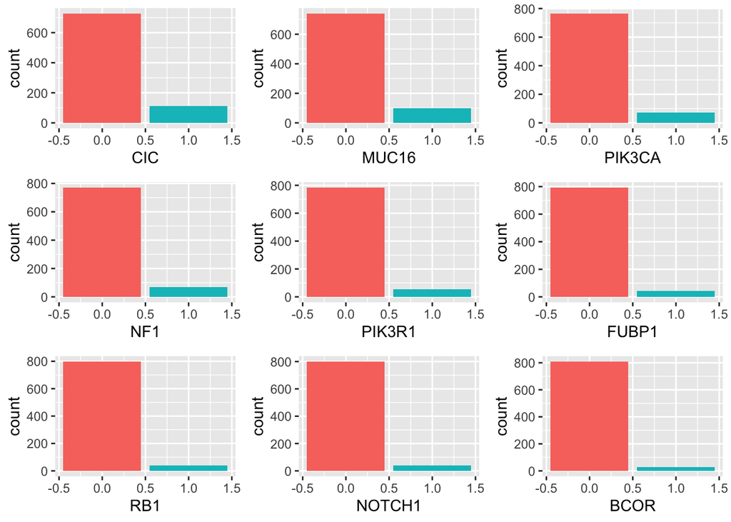

```r
grid.arrange(g10,g11,g12,g13,g14,g15,g16,g17,g18,nrow=3)
```

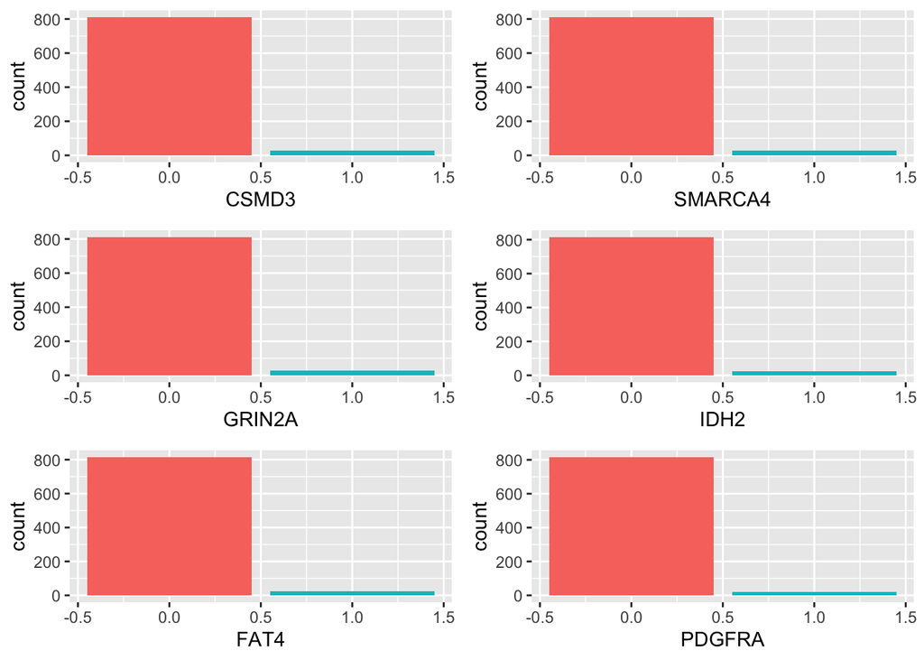

```r
grid.arrange(g19,g20,g21,g22,g23,g24 ,nrow=3)
```

```r
#converting categorical variables to factors

# Loop through each column in the dataframe
for(col in names(df)) {
  # Check if the column is of type integer or character
  if(is.integer(df[[col]]) || is.character(df[[col]])) {
    # Convert the column to a factor
    df[[col]] <- as.factor(df[[col]])
  }
}


# categorical variables labels
categorical_vars <- names(df)[sapply(df, is.factor)]



### CHI - squared analysis on categorical variables ###

# Initialize an empty list to store the results

chi_squared_results <- list()

# Loop through each categorical variable and perform a Chi-Squared test
for (var in categorical_vars) {
  if (var != "Grade") {  # Skip the target variable itself
    # Perform the Chi-Squared test
    test_result <- chisq.test(table(df[[var]], df$Grade))

    # Store the results in the list with the variable name as the key
    chi_squared_results[[var]] <- test_result
  }
}

# Display the results
chi_squared_results
```

```
## $Gender
##
##  Pearson's Chi-squared test with Yates' continuity correction
##
## data:  table(df[[var]], df$Grade)
## X-squared = 2.7821, df = 1, p-value = 0.09532
##
##
## $Race
##
##  Pearson's Chi-squared test
##
## data:  table(df[[var]], df$Grade)
## X-squared = 13.841, df = 3, p-value = 0.00313
##
##
## $IDH1
##
##  Pearson's Chi-squared test with Yates' continuity correction
##
## data:  table(df[[var]], df$Grade)
## X-squared = 417.86, df = 1, p-value < 2.2e-16
##
##
## $TP53
##
##  Pearson's Chi-squared test with Yates' continuity correction
##
## data:  table(df[[var]], df$Grade)
## X-squared = 21.3, df = 1, p-value = 3.927e-06
##
##
## $ATRX
##
##  Pearson's Chi-squared test with Yates' continuity correction
##
## data:  table(df[[var]], df$Grade)
## X-squared = 81.602, df = 1, p-value < 2.2e-16
##
##
```

[output cut: 119 more lines]

```
##
## $FAT4
##
##  Pearson's Chi-squared test with Yates' continuity correction
##
## data:  table(df[[var]], df$Grade)
## X-squared = 0.62854, df = 1, p-value = 0.4279
##
##
## $PDGFRA
##
##  Pearson's Chi-squared test with Yates' continuity correction
##
## data:  table(df[[var]], df$Grade)
## X-squared = 7.5353, df = 1, p-value = 0.00605
```

[figure not shown]

```r
# ANOVA for 'Age_at_diagnosis' across different 'Grade' groups
anova_result <- aov(Age_at_diagnosis ~ Grade, data = df)
# summary(anova_result)



# pairs panels
pairs.panels(df)
```

3. DATA cleaning

### Detection of outliers

- I checked for outliers only in the age_at_diagnosis column as its the only numerical column
- there were no outliers detected
- since the rubric suggested to randomly impute missing data , ive done so in age column , I could have randomly removed data from the other categorical variabels and replaced it with **mode** but I am not going to do so .

### DATA imputation

- I have randomly sampled out 10% of age_by_diagnosis column and imputed it with the median

### Encoding of data

The data is already been Dummy coded and hence no encoding was required and hence not done.

### PCA

PCA is more effective with continuous data. Since most of my data is categorical, the application of PCA might not be straightforward or meaningful

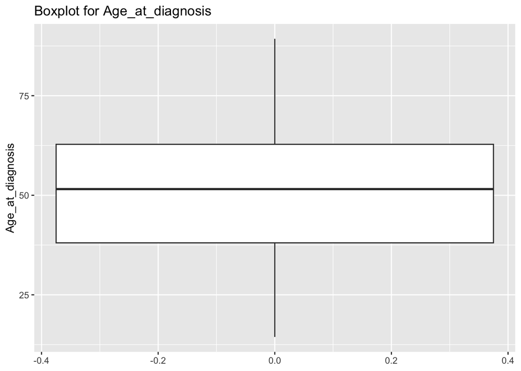

```r
##############################
###  OUTLIER DETECTION     ###
##############################

# Boxplot for visual inspection of outliers
ggplot(df, aes(y = Age_at_diagnosis)) +
  geom_boxplot() +
  labs(title = "Boxplot for Age_at_diagnosis")
```

```r
##################################
### Missing Value Imputation   ###
#################################


# Set a seed for reproducibility
set.seed(123)


# Randomly remove values:
sample_size <- round(0.10 * nrow(df))  # 10% of rows
missing_indices <- sample(1:nrow(df), sample_size)

# Set these values to NA
df$Age_at_diagnosis[missing_indices] <- NA

#checking missing values
sum(is.na(df))
```

```
## [1] 84
```

```r
# Calculate the median of the non-missing values
median_age <- median(df$Age_at_diagnosis, na.rm = TRUE)

# Replace missing values with the median
df$Age_at_diagnosis[is.na(df$Age_at_diagnosis)] <- median_age

#checking if immputed correctly
sum(is.na(df))
```

```
## [1] 0
```

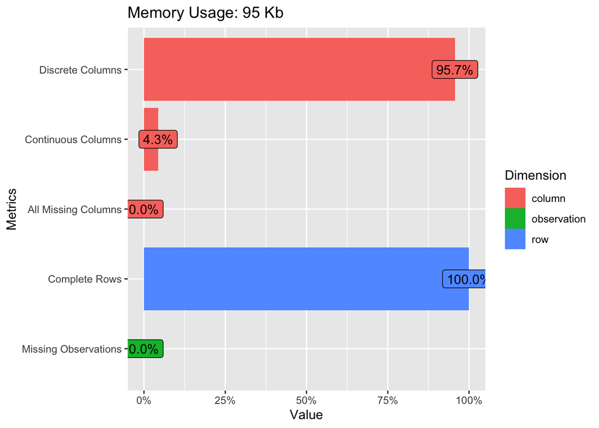

```r
#############################
### Feature Engineering ####
############################

# Dropping the Gender column because it shows no statistical significance with the Target variable
df <- df[-2]

plot_intro(df)
```

```r
str(df)
```

```
## 'data.frame':    839 obs. of  23 variables:
##  $ Grade           : Factor w/ 2 levels "0","1": 1 1 1 1 1 1 1 1 1 1 ...
##  $ Age_at_diagnosis: num  51.3 38.7 35.2 32.8 31.5 ...
##  $ Race            : Factor w/ 4 levels "0","1","2","3": 1 1 1 1 1 1 1 1 1 1 ...
##  $ IDH1            : Factor w/ 2 levels "0","1": 2 2 2 2 2 2 2 2 2 1 ...
##  $ TP53            : Factor w/ 2 levels "0","1": 1 1 2 2 2 1 2 2 2 1 ...
##  $ ATRX            : Factor w/ 2 levels "0","1": 1 1 2 2 2 2 1 2 2 1 ...
##  $ PTEN            : Factor w/ 2 levels "0","1": 1 1 1 1 1 1 1 1 1 1 ...
##  $ EGFR            : Factor w/ 2 levels "0","1": 1 1 1 1 1 1 1 1 1 1 ...
##  $ CIC             : Factor w/ 2 levels "0","1": 1 2 1 1 1 1 1 1 1 1 ...
##  $ MUC16           : Factor w/ 2 levels "0","1": 1 1 1 2 1 1 1 1 1 1 ...
##  $ PIK3CA          : Factor w/ 2 levels "0","1": 2 1 1 1 1 1 1 1 1 1 ...
##  $ NF1             : Factor w/ 2 levels "0","1": 1 1 1 1 1 1 1 1 1 1 ...
##  $ PIK3R1          : Factor w/ 2 levels "0","1": 1 1 1 2 1 1 1 1 1 1 ...
##  $ FUBP1           : Factor w/ 2 levels "0","1": 2 1 1 1 1 1 1 1 1 1 ...
##  $ RB1             : Factor w/ 2 levels "0","1": 1 1 1 1 1 1 1 1 1 1 ...
##  $ NOTCH1          : Factor w/ 2 levels "0","1": 1 1 1 1 1 1 1 1 1 1 ...
##  $ BCOR            : Factor w/ 2 levels "0","1": 1 1 1 1 1 1 1 1 1 1 ...
##  $ CSMD3           : Factor w/ 2 levels "0","1": 1 1 1 1 1 1 1 1 1 1 ...
##  $ SMARCA4         : Factor w/ 2 levels "0","1": 1 1 1 1 1 1 1 1 1 1 ...
##  $ GRIN2A          : Factor w/ 2 levels "0","1": 1 1 1 1 1 1 1 1 1 1 ...
##  $ IDH2            : Factor w/ 2 levels "0","1": 1 1 1 1 1 1 1 1 1 1 ...
##  $ FAT4            : Factor w/ 2 levels "0","1": 1 1 1 2 1 1 1 1 1 1 ...
##  $ PDGFRA          : Factor w/ 2 levels "0","1": 1 1 1 1 1 1 1 1 1 1 ...
```

```r
### removing the gender column from copy data
c_df <- c_df[-2]

# str(c_df)

# normalizing Age column using scale()
df$Age_at_diagnosis <- scale(df$Age_at_diagnosis)
c_df$Age_at_diagnosis <- scale(c_df$Age_at_diagnosis)
```

4. Model Construction & Evaluation

### Creation of training & validation subsets

- I did data splitting in 75:25 ratio
- Partitioned the data using createDataPartition function from the caret package.

### Construction of the models

- I built 4 models which are as follows:
  - k-Nearest Neighbors(knn() from *class* package)
  - Naive- Bayes (NaiveBayes() from *klaR* package )
  - Logistic Regression (glm)
  - Support Vector Machine (ksvm)
- I chose these models as my dataset has combination of continous and categorical data , while most data is categorical in terms of gene mutations and these models aim to predict data better for classifciation

### Test-Train SPLIT

```r
#################################################
### Creation of training & validation subsets ###
#################################################

df$Grade <- as.factor(df$Grade)

# set seed for reproducebility
set.seed(123)

#Splitting the dataset into 75:25 ratio
index <- createDataPartition(df$Grade, p=0.75, list = FALSE, times = 1)


#Using categorical dataset for glm,SVM , KNN and Naive Bayes
training_data_factor <-df[index, ]
testing_data_factor <- df[-index, ]

# Preparing the data labels for knn
train_labels <- training_data_factor$Grade
test_labels <- testing_data_factor$Grade
```

```r
###########################
### k-Nearest Neighbors ###
###########################

k <- 5
knn_pred <- knn(train = training_data_factor[-1], test = testing_data_factor[-1], cl = train_labels, k = k)

# Evaluating the model
conf_matrix <- table(Predicted = knn_pred, Actual = testing_data_factor$Grade)
print(conf_matrix)
```

```
##          Actual
## Predicted   0   1
##         0 103   9
##         1  18  79
```

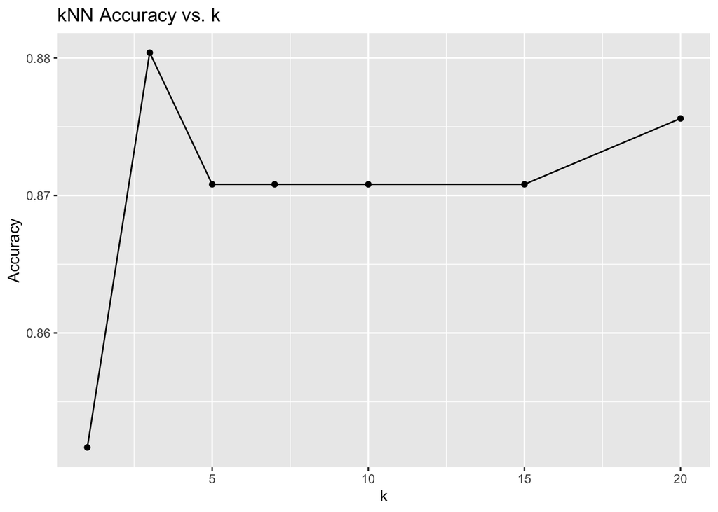

```r
# checking accuarcy for different k valaues
results <- data.frame(k = integer(), accuracy = numeric())
for (k in c(1, 3, 5, 7, 10, 15, 20)) {
  knn_predictions <- knn(train = training_data_factor[-1] , test = testing_data_factor[-1], cl = train_labels, k = k)
  acc <- sum(knn_predictions == test_labels) / length(test_labels)
  results <- rbind(results, data.frame(k = k, accuracy = acc))
}

# Plotting accuracy vs. k
ggplot(results, aes(x = k, y = accuracy)) +
  geom_line() +
  geom_point() +
  labs(title = "kNN Accuracy vs. k", x = "k", y = "Accuracy")
```

```r
# Calculate accuracy
accuracy_knn <- sum(diag(conf_matrix)) / sum(conf_matrix)


# Replacing  model's predictions and actual labels
predictions <- knn_pred  # model's predictions
actuals <- test_labels # Actual labels from test data

conf_matrix_func <- confusionMatrix(predictions , actuals)

# Converting to factor if they are not already
predictions <- as.factor(predictions)
actuals <- as.factor(actuals)

# Precision and Recall
precision_knn <- conf_matrix_func$byClass['Precision']
recall_knn <- conf_matrix_func$byClass['Recall']

# F1 Score
F1_score_knn <- 2 * (precision_knn * recall_knn) / (precision_knn + recall_knn)

# making predictions numeric for AUC calculation
numeric_predictions <- as.numeric(levels(predictions))[predictions]
numeric_actuals <- as.numeric(levels(actuals))[actuals]
actuals_numeric <- as.numeric(as.character(actuals))


numeric_predictions
```

```
##   [1] 0 0 0 0 0 0 0 0 0 0 0 0 1 0 0 1 0 0 1 0 0 0 0 0 1 0 0 0 0 0 0 0 1 0 1 0 0
##  [38] 0 0 0 0 0 1 0 0 1 0 0 1 1 0 0 1 0 0 0 0 1 1 0 0 0 0 0 0 1 0 0 0 0 0 0 1 0
##  [75] 0 0 0 0 0 0 0 0 0 0 0 0 0 0 0 0 0 0 0 0 1 0 0 0 0 0 0 0 0 0 0 0 0 0 0 0 0
## [112] 0 0 1 1 0 0 0 0 0 0 1 1 1 1 1 1 0 1 1 1 1 1 1 1 1 1 1 1 1 1 1 1 1 1 1 1 1
## [149] 1 1 1 1 1 1 1 1 1 1 1 1 1 1 1 1 1 1 1 1 1 1 1 1 0 1 0 0 1 1 1 1 1 1 1 1 1
## [186] 1 1 1 0 1 1 1 0 1 1 1 1 0 1 1 1 1 1 1 1 1 1 0 0
```

```r
actuals
```

```
##   [1] 0 0 0 0 0 0 0 0 0 0 0 0 0 0 0 0 0 0 0 0 0 0 0 0 0 0 0 0 0 0 0 0 0 0 0 0 0
##  [38] 0 0 0 0 0 0 0 0 0 0 0 0 0 0 0 0 0 0 0 0 0 0 0 0 0 0 0 0 0 0 0 0 0 0 0 0 0
##  [75] 0 0 0 0 0 0 0 0 0 0 0 0 0 0 0 0 0 0 0 0 0 0 0 0 0 0 0 0 0 0 0 0 0 0 0 0 0
## [112] 0 0 0 0 0 0 0 0 0 0 1 1 1 1 1 1 1 1 1 1 1 1 1 1 1 1 1 1 1 1 1 1 1 1 1 1 1
## [149] 1 1 1 1 1 1 1 1 1 1 1 1 1 1 1 1 1 1 1 1 1 1 1 1 1 1 1 1 1 1 1 1 1 1 1 1 1
## [186] 1 1 1 1 1 1 1 1 1 1 1 1 1 1 1 1 1 1 1 1 1 1 1 1
## Levels: 0 1
```

```r
roc_curve <- roc(response = actuals_numeric, predictor = numeric_predictions)

AUC_knn <- auc(roc_curve)

# Print Metrics
print(paste("Accuracy:", accuracy_knn))
```

```
## [1] "Accuracy: 0.870813397129187"
```

```r
print(paste("Precision:", precision_knn))
```

```
## [1] "Precision: 0.919642857142857"
```

```r
print(paste("Recall:", recall_knn))
```

```
## [1] "Recall: 0.851239669421488"
```

```r
print(paste("F1 Score:", F1_score_knn))
```

```
## [1] "F1 Score: 0.88412017167382"
```

```r
print(paste("AUC:", AUC_knn))
```

```
## [1] "AUC: 0.87448347107438"
```

```r
###########################
###     Naive Bayes     ###
###########################


naive_bayes <- NaiveBayes(Grade ~ . , data = training_data_factor)
# summary(naive_bayes)
naive_bayes_predictions <- predict(naive_bayes , newdata = testing_data_factor)
# summary(naive_bayes_predictions)


# Evaluating the model
conf_matrix_nb <- table(Predicted = naive_bayes_predictions$class, Actual = testing_data_factor$Grade)

print(conf_matrix_nb)
```

```
##          Actual
## Predicted   0   1
##         0 103   8
##         1  18  80
```

```r
# Calculate accuracy
accuaracy_nb <- sum(diag(conf_matrix_nb)) / sum(conf_matrix_nb)
print(paste("Accuracy:", accuaracy_nb))
```

```
## [1] "Accuracy: 0.875598086124402"
```

```r
# Replacing  model's predictions and actual labels
predictions <- naive_bayes_predictions$class  # model's predictions
actuals <- testing_data_factor$Grade # Actual labels from test data

conf_matrix_func <- confusionMatrix(predictions , actuals)

# Converting to factor
predictions <- as.factor(predictions)
actuals <- as.factor(actuals)

# Precision and Recall
precision_nb <- conf_matrix_func$byClass['Precision']
recall_nb <- conf_matrix_func$byClass['Recall']

# F1 Score
F1_score_nb <- 2 * (precision_nb * recall_nb) / (precision_nb + recall_nb)

# making predictions numeric for AUC calculation
numeric_predictions <- as.numeric(levels(predictions))[predictions]
numeric_actuals <- as.numeric(levels(actuals))[actuals]


AUC_nb <- auc(roc(actuals, numeric_predictions))

# Print Metrics
print(paste("Accuracy:", accuaracy_nb))
```

```
## [1] "Accuracy: 0.875598086124402"
```

```r
print(paste("Precision:", precision_nb))
```

```
## [1] "Precision: 0.927927927927928"
```

```r
print(paste("Recall:", recall_nb))
```

```
## [1] "Recall: 0.851239669421488"
```

```r
print(paste("F1 Score:", F1_score_nb))
```

```
## [1] "F1 Score: 0.887931034482759"
```

```r
print(paste("AUC:", AUC_nb))
```

```
## [1] "AUC: 0.880165289256198"
```

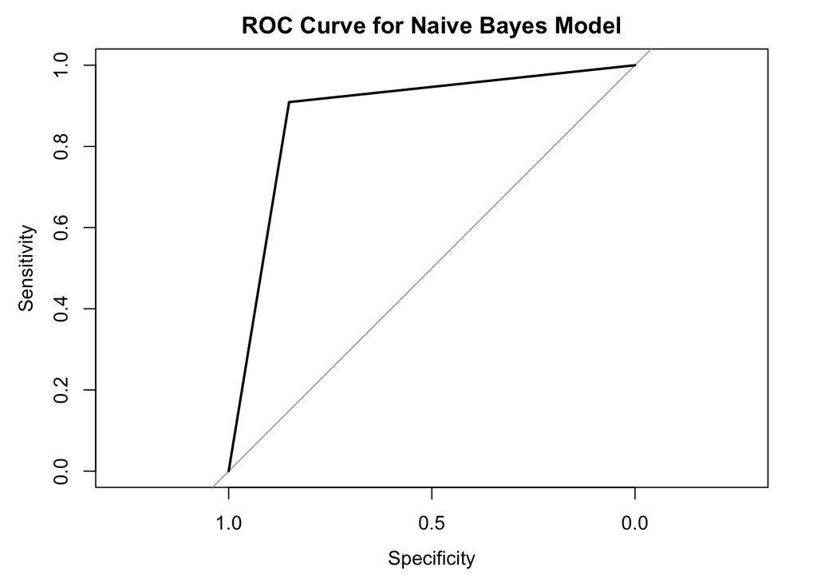

```r
# Generating the ROC curve to check for overfitting
roc_curve <- roc(testing_data_factor$Grade, numeric_predictions)
# Plotting the ROC curve
plot(roc_curve, main = "ROC Curve for Naive Bayes Model")
```

```r
###########################
### Logistic Regression ###
###########################

#Building the logistic regression model using glm function
lm <- glm( Grade~., data = training_data_factor, family = "binomial" )

# Observing the summary of the model
# summary(lm)

# Make predictions on the test set
pred_lm <- predict(lm , testing_data_factor ,type = "response")

# Convert probabilities to binary outcomes based on a 0.5 cutoff
pred_classes <- ifelse(pred_lm > 0.5, 1, 0)


# Evaluating the model
conf_matrix_glm <- table(Predicted = pred_classes, Actual = testing_data_factor$Grade)

print(conf_matrix_glm)
```

```
##          Actual
## Predicted   0   1
##         0 104   7
##         1  17  81
```

```r
# Calculate accuracy
accuracy_lm <- sum(diag(conf_matrix_glm)) / sum(conf_matrix_glm)


# Replacing  model's predictions and actual labels
predictions_lm <- pred_classes  # model's predictions
actuals_lm <- testing_data_factor$Grade # Actual labels from test data

# Converting to factor
predictions_lm <- as.factor(predictions_lm)
actuals_lm <- as.factor(actuals_lm)


# calculating COnfusion matrix with caret package
conf_matrix_func <- confusionMatrix(predictions_lm , actuals_lm)



# Precision and Recall
precision_lm <- conf_matrix_func$byClass['Precision']
recall_lm <- conf_matrix_func$byClass['Recall']

# F1 Score
F1_score_lm <- 2 * (precision_lm * recall_lm) / (precision_lm + recall_lm)

# making predictions numeric for AUC calculation
numeric_predictions <- as.numeric(levels(predictions_lm))[predictions_lm]
numeric_actuals <- as.numeric(levels(actuals_lm))[actuals_lm]

# AUC and roc
AUC_lm <- auc(roc(actuals_lm, numeric_predictions))

# Print Metrics
print(paste("Accuracy:", accuracy_lm))
```

```
## [1] "Accuracy: 0.885167464114832"
```

```r
print(paste("Precision:", precision_lm))
```

```
## [1] "Precision: 0.936936936936937"
```

```r
print(paste("Recall:", recall_lm))
```

```
## [1] "Recall: 0.859504132231405"
```

```r
print(paste("F1 Score:", F1_score_lm))
```

```
## [1] "F1 Score: 0.896551724137931"
```

```r
print(paste("AUC:", AUC_lm))
```

```
## [1] "AUC: 0.889979338842975"
```

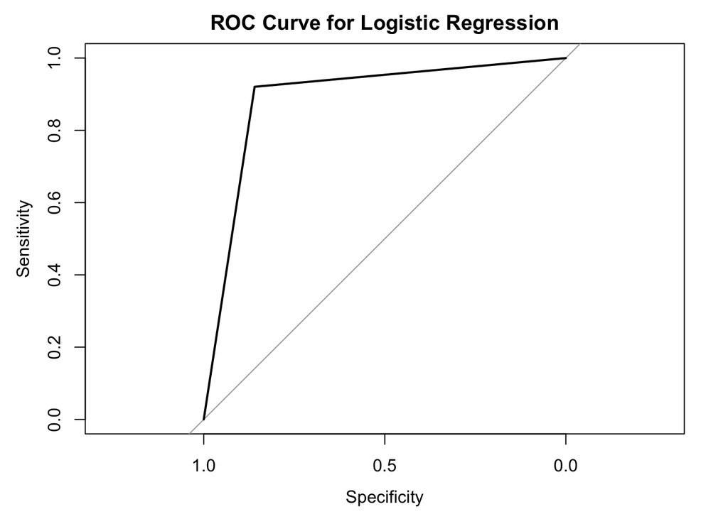

```r
# plottign roc curve for checking overfitting
roc_c <- roc(actuals_lm, numeric_predictions)
plot(roc_c , main =  "ROC Curve for Logistic Regression")
```

```r
##############################
### Support Vector Machine ###
##############################

#Building SVM model with categorical data
svm_model <- ksvm(Grade ~ ., data = training_data_factor,  prob.model=TRUE,kernel="rbfdot")
summary (svm_model)
```

```
## Length  Class   Mode
##      1   ksvm     S4
```

```r
#Predicting outcome of the testing dataset
pred_svm <- predict(svm_model, testing_data_factor)

#Observing first few predictions
head(pred_svm)
```

```
## [1] 0 0 0 0 0 0
## Levels: 0 1
```

```r
pred_svm <- as.factor(pred_svm)

# Evaluating the model
conf_matrix_svm <- table(Predicted = pred_svm, Actual = testing_data_factor$Grade)
print(conf_matrix_svm)
```

```
##          Actual
## Predicted   0   1
##         0 102   5
##         1  19  83
```

```r
# Calculate accuracy
accuracy_svm <- sum(diag(conf_matrix_svm)) / sum(conf_matrix_svm)

# Replacing model's predictions and actual labels
predictions_svm <- pred_svm  # model's predictions
actuals_Svm <- testing_data_factor$Grade # Actual labels from test data

# factors with the same levels
predictions_svm <- factor(predictions_svm, levels = levels(actuals_Svm))
actuals_Svm <- factor(actuals_Svm)

# Calculating confusion matrix with caret package
conf_matrix_func <- confusionMatrix(predictions_svm, actuals_Svm)

# Precision and Recall
precision_svm <- conf_matrix_func$byClass['Precision']
recall_svm <- conf_matrix_func$byClass['Recall']

# F1 Score
F1_score_svm <- 2 * (precision_svm * recall_svm) / (precision_svm + recall_svm)

# Making predictions numeric for AUC calculation
numeric_predictions_svm <- as.numeric(levels(predictions_svm))[predictions_svm]
numeric_Actucals_Svm <- as.numeric(levels(actuals_Svm))[actuals_Svm]

# AUC and ROC
AUC_svm <- auc(roc(actuals_Svm, numeric_predictions_svm))

# Print Metrics
print(paste("Accuracy:", accuracy_svm))
```

```
## [1] "Accuracy: 0.885167464114832"
```

```r
print(paste("Precision:", precision_svm))
```

```
## [1] "Precision: 0.953271028037383"
```

```r
print(paste("Recall:", recall_svm))
```

```
## [1] "Recall: 0.84297520661157"
```

```r
print(paste("F1 Score:", F1_score_svm))
```

```
## [1] "F1 Score: 0.894736842105263"
```

```r
print(paste("AUC:", AUC_svm))
```

```
## [1] "AUC: 0.893078512396694"
```

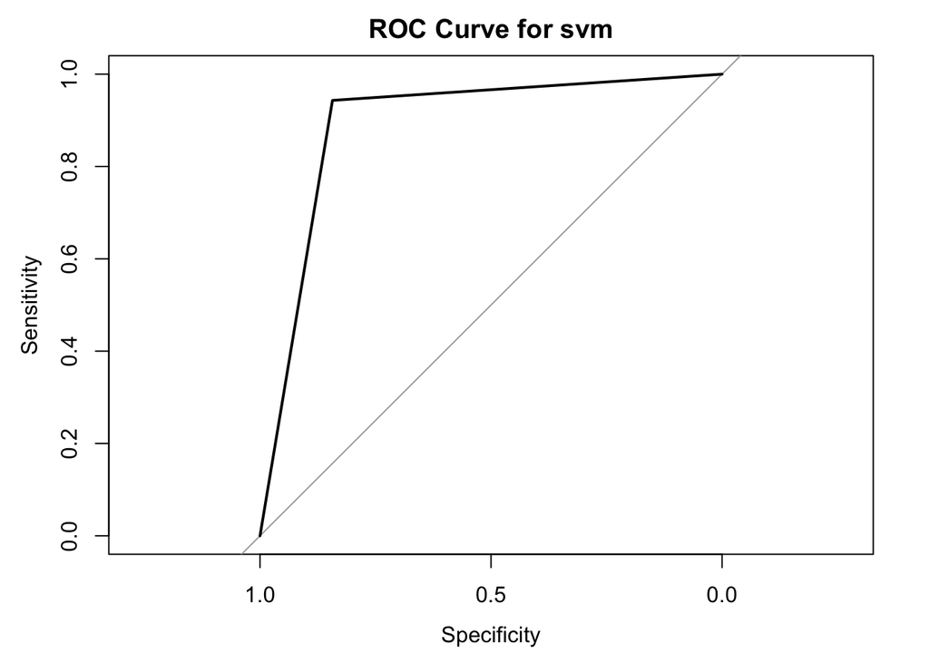

```r
# plottign roc curve for checking overfitting
roc_c <- roc(actuals_Svm, numeric_predictions_svm)
plot(roc_c , main =  "ROC Curve for svm")
```

5. Model Evaluation: I chose the **accuracy**, **precision**, **recall**, **F1 Score** , and **AUC** as my metrics. I selected these metrics because they provide a comprehensive view of the model’s performance. Accuracy measures overall correctness, precision evaluates the model’s ability to make correct positive predictions, recall assesses the model’s ability to capture true positive instances, and the F1 Score balances precision and recall. Additionally, the AUC helps us understand the model’s ability to distinguish between different classes, which is crucial in a **medical classifications**

The k-NN model achieved an accuracy of approximately 87.08, with a precision of 91.96 and recall of 85.12. The F1 Score was approximately 0.8841202, and the Area Under the ROC Curve (AUC) was around 0.8744835.

Naive Bayes performed slightly better, with an accuracy of 87.6%, precision of 92.79%, recall of 85.12%, and an F1 Score of approximately 0.888, with an AUC of around 0.88.

Logistic Regression showed the highest accuracy of approximately 88.5%, precision of 93.69%, recall of 85.95%, F1 Score of approximately 0.897, and AUC of around 0.89.

Lastly, the Support Vector Machine achieved an accuracy of 88.5%, precision of 95.33%, recall of 84.30%, F1 Score of approximately 0.895, and AUC of around 0.893

### k-fold cross-validation for each model

```r
##################################
### 10 - FOLD CROSS VALIDATION ###
################################

set.seed(123)
train_control <- trainControl(method = "cv", number = 10)


### logistic regression ###
glm_fit <- train(Grade ~ ., data = training_data_factor, method = "glm", family = "binomial", trControl = train_control)
print(glm_fit)
```

```
## Generalized Linear Model
##
## 630 samples
##  22 predictor
##   2 classes: '0', '1'
##
## No pre-processing
## Resampling: Cross-Validated (10 fold)
## Summary of sample sizes: 566, 566, 568, 568, 567, 568, ...
## Resampling results:
##
##   Accuracy   Kappa
##   0.8697133  0.7365132
```

```r
### SVM ####
svm_fit <- train(Grade ~ ., data = training_data_factor, method = "svmRadial", trControl = train_control,  tuneLength = 10)
print(svm_fit)
```

```
## Support Vector Machines with Radial Basis Function Kernel
##
## 630 samples
##  22 predictor
##   2 classes: '0', '1'
##
## No pre-processing
## Resampling: Cross-Validated (10 fold)
## Summary of sample sizes: 568, 568, 567, 567, 566, 566, ...
## Resampling results across tuning parameters:
##
##   C       Accuracy   Kappa
##     0.25  0.8461046  0.6888964
##     0.50  0.8524298  0.7024220
##     1.00  0.8460301  0.6891909
##     2.00  0.8461062  0.6881590
##     4.00  0.8397801  0.6742268
##     8.00  0.8398049  0.6742479
##    16.00  0.8396801  0.6733104
##    32.00  0.8364799  0.6670780
##    64.00  0.8429051  0.6805491
##   128.00  0.8460805  0.6873505
##
## Tuning parameter 'sigma' was held constant at a value of 0.04527486
## Accuracy was used to select the optimal model using the largest value.
## The final values used for the model were sigma = 0.04527486 and C = 0.5.
```

```r
#### KNN ###
set.seed(123)

# Number of folds
k_folds <- 10

# Create folds
folds <- createFolds(training_data_factor$Grade, k = k_folds, list = TRUE)

# Initialize vector to store results
knn_results <- vector("list", length = k_folds)

# Loop over folds
for(i in 1:k_folds){
  # Split the data
  train_fold <- training_data_factor[-folds[[i]], ]
  test_fold <- training_data_factor[folds[[i]], ]

  # Fit kNN model (choose appropriate k)
  k <- 5
  knn_fit <- knn(train = train_fold[-1], test = test_fold[-1], cl = train_fold$Grade, k = k)

  # Evaluate the model
  knn_results[[i]] <- confusionMatrix(knn_fit, test_fold$Grade)
}

# Calculate average performance
mean_accuracy_knn <- mean(sapply(knn_results, function(x) x$overall['Accuracy']))


mean_accuracy_knn
```

```
## [1] 0.8463582
```

```r
### Naive Bayes ###
# Create folds
folds <- createFolds(training_data_factor$Grade, k = k_folds, list = TRUE)

# Initialize vector to store results
nb_results <- vector("list", length = k_folds)

# Loop over folds
for(i in 1:k_folds){
  # Split the data
  train_fold <- training_data_factor[-folds[[i]], ]
  test_fold <- training_data_factor[folds[[i]], ]

  # Fit Naive Bayes model
  nb_fit <- NaiveBayes(Grade ~ ., data = train_fold)

  # Make predictions
  nb_pred <- predict(nb_fit, newdata = test_fold)

  # Evaluate the model
  nb_results[[i]] <- confusionMatrix(nb_pred$class, test_fold$Grade)
}

# Calculate average performance
mean_accuracy_nb <- mean(sapply(nb_results, function(x) x$overall['Accuracy']))


mean_accuracy_nb
```

```
## [1] 0.8604407
```

1. K-Nearest Neighbors (kNN):

Number of neighbors (k): 5. Average accuracy: Approximately 0.8463582 Observation: The kNN model, with 5 neighbors, shows a strong ability to classify the data correctly. An accuracy of around 84.64% indicates that the model is performing well. However, it’s worth considering testing different values of k to see if the accuracy can be improve

-General Takeaways:

6. model Tuning and ensemble model

### model tuning

- I’ve meticulously tuned my predictive models to optimize their performance.
- For the k-Nearest Neighbors model, I determined the best number of neighbors, balancing model complexity and accuracy.
- In Logistic Regression, I applied a stepwise backward method, selectively using the most significant features.
- For the Support Vector Machine, I tuned crucial parameters like cost and gamma to enhance its generalization ability.

```r
########################
### Tuning of Models ###
########################

### Tuning k for kNN ###
best_k <- 1
best_accuracy <- 0

for (k in 1:20) {
  set.seed(123) # for reproducibility
  knn_pred_t <- knn(train = training_data_factor[-1], test = testing_data_factor[-1], cl = train_labels, k = k)
  current_accuracy <- sum(knn_pred_t == testing_data_factor$Grade) / length(testing_data_factor$Grade)

  if (current_accuracy > best_accuracy) {
    best_accuracy <- current_accuracy
    best_k <- k
  }
}

print(paste("Best k:", best_k))
```

```
## [1] "Best k: 4"
```

```r
# Using the best k
knn_pred_t <- knn(train = training_data_factor[-1], test = testing_data_factor[-1], cl = train_labels, k = best_k)

# Calculating metrics for kNN
conf_matrix_knn_t <- confusionMatrix(as.factor(knn_pred_t), as.factor(testing_data_factor$Grade))
# conf_matrix_knn_t
accuracy_knn_t <- conf_matrix_knn_t$overall['Accuracy']
precision_knn_t <- conf_matrix_knn_t$byClass['Precision']
recall_knn_t <- conf_matrix_knn_t$byClass['Recall']
F1_score_knn_t <- 2 * (precision_knn_t * recall_knn_t) / (precision_knn_t + recall_knn_t)
AUC_knn_t <- auc(roc(as.numeric(testing_data_factor$Grade), as.numeric(as.factor(knn_pred_t))))

print(paste("Accuracy for kNN:", accuracy_knn_t))
```

```
## [1] "Accuracy for kNN: 0.880382775119617"
```

```r
print(paste("Precision for kNN:", precision_knn_t))
```

```
## [1] "Precision for kNN: 0.944444444444444"
```

```r
print(paste("Recall for kNN:", recall_knn_t))
```

```
## [1] "Recall for kNN: 0.84297520661157"
```

```r
print(paste("F1 Score for kNN:", F1_score_knn_t))
```

```
## [1] "F1 Score for kNN: 0.890829694323144"
```

```r
print(paste("AUC for kNN:", AUC_knn_t))
```

```
## [1] "AUC for kNN: 0.887396694214876"
```

```r
### Logistic Regression ###
# Stepwise backward logistic regression
stepwise_model <- step(lm, direction = "backward")
```

```r
# Predictions using stepwise model
step_pred <- predict(stepwise_model, newdata = testing_data_factor, type = "response")
step_classes <- ifelse(step_pred > 0.5, 1, 0)

# Metrics for Stepwise Logistic Regression
conf_matrix_step <- confusionMatrix(as.factor(step_classes), as.factor(testing_data_factor$Grade))
accuracy_step <- conf_matrix_step$overall['Accuracy']
precision_step <- conf_matrix_step$byClass['Precision']
recall_step <- conf_matrix_step$byClass['Recall']
F1_score_step <- 2 * (precision_step * recall_step) / (precision_step + recall_step)
AUC_step <- auc(roc(as.numeric(testing_data_factor$Grade), as.numeric(as.factor(step_classes))))
print(paste("Accuracy for Logistic Regression:", accuracy_step))
```

```
## [1] "Accuracy for Logistic Regression: 0.885167464114832"
```

```r
print(paste("Precision for Logistic Regression:", precision_step))
```

```
## [1] "Precision for Logistic Regression: 0.936936936936937"
```

```r
print(paste("Recall for Logistic Regression:", recall_step))
```

```
## [1] "Recall for Logistic Regression: 0.859504132231405"
```

```r
print(paste("F1 Score for Logistic Regression:", F1_score_step))
```

```
## [1] "F1 Score for Logistic Regression: 0.896551724137931"
```

```r
print(paste("AUC for Logistic Regression:", AUC_step))
```

```
## [1] "AUC for Logistic Regression: 0.889979338842975"
```

```r
### SVM ###
# Tuning SVM
tuned_svm <- tune.svm(Grade ~ ., data = training_data_factor, gamma = 10^(-6:-1), cost = 10^(1:2))

# Best SVM model
best_svm <- tuned_svm$best.model

# Predictions using the best SVM model
pred_svm <- predict(best_svm, testing_data_factor)

# Metrics for SVM
conf_matrix_svm_t <- confusionMatrix(as.factor(pred_svm), as.factor(testing_data_factor$Grade))
conf_matrix_svm_t
```

```
## Confusion Matrix and Statistics
##
##           Reference
## Prediction   0   1
##          0 102   8
##          1  19  80
##
##                Accuracy : 0.8708
##                  95% CI : (0.8176, 0.9131)
##     No Information Rate : 0.5789
##     P-Value [Acc > NIR] : < 2e-16
##
##                   Kappa : 0.7395
##
##  Mcnemar's Test P-Value : 0.05429
##
##             Sensitivity : 0.8430
##             Specificity : 0.9091
##          Pos Pred Value : 0.9273
##          Neg Pred Value : 0.8081
##              Prevalence : 0.5789
##          Detection Rate : 0.4880
##    Detection Prevalence : 0.5263
##       Balanced Accuracy : 0.8760
##
##        'Positive' Class : 0
##
```

```r
accuracy_svm <- conf_matrix_svm_t$overall['Accuracy']
precision_svm <- conf_matrix_svm_t$byClass['Precision']
recall_svm <- conf_matrix_svm_t$byClass['Recall']
F1_score_svm <- 2 * (precision_svm * recall_svm) / (precision_svm + recall_svm)
AUC_svm <- auc(roc(as.numeric(testing_data_factor$Grade), as.numeric(as.factor(pred_svm))))
print(paste("Accuracy for SVM:", accuracy_svm))
```

```
## [1] "Accuracy for SVM: 0.870813397129187"
```

```r
print(paste("Precision for SVM:", precision_svm))
```

```
## [1] "Precision for SVM: 0.927272727272727"
```

```r
print(paste("Recall for SVM:", recall_svm))
```

```
## [1] "Recall for SVM: 0.84297520661157"
```

```r
print(paste("F1 Score for SVM:", F1_score_svm))
```

```
## [1] "F1 Score for SVM: 0.883116883116883"
```

```r
print(paste("AUC for SVM:", AUC_svm))
```

```
## [1] "AUC for SVM: 0.87603305785124"
```

### Construction of ensemble model

```r
# Ensemble prediction function for entire test dataset
predictOutcomeClass <- function(newdata, nb_model, glm_model, knn_model, train_data, train_labels, k) {
  # Store ensemble predictions
  ensemble_predictions <- character(nrow(newdata))

  for (i in 1:nrow(newdata)) {
    # Predict using Naive Bayes
    nb_prediction <- predict(nb_model, newdata = newdata[i, , drop = FALSE], type = "class")
    nb_prediction <- as.character(nb_prediction)

    # Predict using Logistic Regression
    glm_prob <- predict(glm_model, newdata = newdata[i, , drop = FALSE], type = "response")
    glm_prediction <- ifelse(glm_prob > 0.5, "1", "0")

    # Predict using kNN
    knn_prediction <- knn(train = train_data[-1], test = newdata[i, -1, drop = FALSE], cl = train_labels, k = k)

    # Combine predictions
    predictions <- c(nb_prediction, glm_prediction, knn_prediction)

    # Use table to count the occurrences of each prediction
    tbl <- table(predictions)

    # Calculate majority vote
    majority_vote <- names(which.max(tbl))

    # Store the majority vote
    ensemble_predictions[i] <- majority_vote
  }

  return(as.factor(ensemble_predictions))
}

# Predicting the outcome using the ensemble model for the entire test dataset
ensemble_predictions <- predictOutcomeClass(testing_data_factor, naive_bayes, lm, knn_pred_t,
                                            training_data_factor,
                                            training_data_factor$Grade,
                                            k=4) #  tuned k value from kNN

# Metrics Calculation
conf_matrix_ensemble <- confusionMatrix(ensemble_predictions, testing_data_factor$Grade)
accuracy_ensemble <- conf_matrix_ensemble$overall['Accuracy']
precision_ensemble <- conf_matrix_ensemble$byClass['Precision']
recall_ensemble <- conf_matrix_ensemble$byClass['Recall']
F1_score_ensemble <- 2 * (precision_ensemble * recall_ensemble) / (precision_ensemble + recall_ensemble)
AUC_ensemble <- auc(roc(as.numeric(testing_data_factor$Grade), as.numeric(ensemble_predictions)))

# Print Metrics
print(paste("Ensemble Model Accuracy:", accuracy_ensemble))
```

```
## [1] "Ensemble Model Accuracy: 0.885167464114832"
```

```r
print(paste("Ensemble Model Precision:", precision_ensemble))
```

```
## [1] "Ensemble Model Precision: 0.936936936936937"
```

```r
print(paste("Ensemble Model Recall:", recall_ensemble))
```

```
## [1] "Ensemble Model Recall: 0.859504132231405"
```

```r
print(paste("Ensemble Model F1 Score:", F1_score_ensemble))
```

```
## [1] "Ensemble Model F1 Score: 0.896551724137931"
```

```r
print(paste("Ensemble Model AUC:", AUC_ensemble))
```

```
## [1] "Ensemble Model AUC: 0.889979338842975"
```

### ensemble prediction on single data point

```r
# Ensemble prediction function
predictOutcomeClass <- function(newdata, nb_model, glm_model, knn_model, train_data, train_labels) {
  # Predict using Naive Bayes
  nb_prediction <- predict(nb_model, newdata = newdata, type = "class")
  nb_prediction <- as.character(nb_prediction)

  # Predict using Logistic Regression and convert probabilities to class prediction
  glm_prob <- predict(glm_model, newdata = newdata, type = "response")
  glm_prediction <- ifelse(glm_prob > 0.5, "1", "0")

  # Predict using kNN
  knn_prediction <- knn(train = train_data[-1], test = newdata[-1], cl = train_labels, k = k)

  # Combine predictions
  predictions <- c(nb_prediction, glm_prediction, knn_prediction)

  # Use table to count the occurrences of each prediction
  tbl <- table(predictions)

  # Calculate majority vote
  majority_vote <- names(which.max(tbl))

  return(majority_vote)
}

# Selecting a random row from the test data
set.seed(123)
random_row <- testing_data_factor[sample(nrow(testing_data_factor), 1), ]

# Predicting the outcome using the ensemble model
ensemble_prediction <- predictOutcomeClass(random_row, naive_bayes,lm, knn_pred,
                                           training_data_factor,
                                           training_data_factor$Grade)

# Printing the ensemble prediction
print(paste("Ensemble Model Prediction:", ensemble_prediction))
```

```
## [1] "Ensemble Model Prediction: 1"
```

The ensemble model on single data point predicts the 1 or GBM (Glioblastoma Multiforme) on the basis of analysis of all 3 models combined based on the randomly selected row from the test dataset